# 📊 Customer Churn Analysis for Telco Company

## 👤 Author: Sarah Ahmed

**Objective:**  
This project aims to analyze customer churn for a telecommunications company using machine learning and exploratory data analysis (EDA). The goal is to identify key drivers of churn and provide actionable insights that can help improve customer retention strategies.

**Dataset Source:**  
[Telco Customer Churn Dataset](https://www.kaggle.com/datasets/blastchar/telco-customer-churn)

**Tech Stack:**

- Python, Pandas, NumPy, Matplotlib, Seaborn
- Scikit-learn for modeling (Logistic Regression, Random Forest)

### 📦 Step 1: Importing Essential Libraries

In this step, we import all the necessary Python libraries required for our Customer Churn Analysis project:

- **pandas** and **numpy** for data manipulation and numerical operations
- **matplotlib** and **seaborn** for data visualization
- **sklearn.model_selection** to split the data into training and testing sets
- **sklearn.preprocessing** for encoding categorical variables
- **sklearn.metrics** for evaluating model performance
- **sklearn.linear_model**, **ensemble**, and **tree** modules to build different machine learning models (Logistic Regression, Random Forest, and Decision Tree)

```python
# importing essential libaries.
import pandas as pd               # for data manipulation
import numpy as np                # for numerical operations
import matplotlib.pyplot as plt   # for visualization
import seaborn as sns             # for advanced plots
from sklearn.model_selection import train_test_split  # for splitting data
from sklearn.preprocessing import LabelEncoder        # for encoding categorical variables
from sklearn.metrics import classification_report, confusion_matrix, accuracy_score
from sklearn.linear_model import LogisticRegression   # example model
from sklearn.ensemble import RandomForestClassifier   # example model
from sklearn.tree import DecisionTreeClassifier       # example model
```

### 📄 Step 2: Load and Preview the Dataset

We load the Telco Customer Churn dataset using `pandas` and display the first few rows using `.head()` to get an initial look at the structure and content of the data.

This helps us understand:

- What kind of columns are present
- If there are any immediately noticeable issues (e.g., nulls or inconsistent values)
- The general format of the dataset

```python
df = pd.read_csv("add relevant file_path.csv")
# preview data.
print("sample data:")
print(df.head())
```

```
sample data:
   customerID  gender  SeniorCitizen Partner Dependents  tenure PhoneService  \
0  7590-VHVEG  Female              0     Yes         No       1           No
1  5575-GNVDE    Male              0      No         No      34          Yes
2  3668-QPYBK    Male              0      No         No       2          Yes
3  7795-CFOCW    Male              0      No         No      45           No
4  9237-HQITU  Female              0      No         No       2          Yes

      MultipleLines InternetService OnlineSecurity  ... DeviceProtection  \
0  No phone service             DSL             No  ...               No
1                No             DSL            Yes  ...              Yes
2                No             DSL            Yes  ...               No
3  No phone service             DSL            Yes  ...              Yes
4                No     Fiber optic             No  ...               No

  TechSupport StreamingTV StreamingMovies        Contract PaperlessBilling  \
0          No          No              No  Month-to-month              Yes
1          No          No              No        One year               No
2          No          No              No  Month-to-month              Yes
3         Yes          No              No        One year               No
4          No          No              No  Month-to-month              Yes

               PaymentMethod MonthlyCharges  TotalCharges Churn
0           Electronic check          29.85         29.85    No
1               Mailed check          56.95        1889.5    No
2               Mailed check          53.85        108.15   Yes
3  Bank transfer (automatic)          42.30       1840.75    No
4           Electronic check          70.70        151.65   Yes

[5 rows x 21 columns]
```

### 🧾 Step 3: Inspect Dataset Structure and Data Types

We use the `.info()` function to display basic information about the dataset, including:

- The number of rows and columns
- The data types of each column
- The count of non-null values in each column

This helps identify:

- Potential data type issues (e.g., numerical columns stored as strings)
- Columns with missing values that may need cleaning or imputation

```python
# basic info
print("\nbasic info:")
print(df.info())
```

[output not shown]

### 🔍 Step 4: Check for Missing Values

We check for missing values in the dataset using `.isnull().sum()`. This step is essential for identifying incomplete data, which can affect model training and performance.

If any columns have missing or null values, we'll handle them in the upcoming data cleaning steps by either imputing or removing them.

```python
# check for missing values.
print("\nmissing values:")
print(df.isnull().sum())
```

```
missing values:
customerID          0
gender              0
SeniorCitizen       0
Partner             0
Dependents          0
tenure              0
PhoneService        0
MultipleLines       0
InternetService     0
OnlineSecurity      0
OnlineBackup        0
DeviceProtection    0
TechSupport         0
StreamingTV         0
StreamingMovies     0
Contract            0
PaperlessBilling    0
PaymentMethod       0
MonthlyCharges      0
TotalCharges        0
Churn               0
dtype: int64
```

### 🧹 Step 5: Drop Irrelevant Columns

We remove the `customerID` column from the dataset, as it serves only as a unique identifier and does not contribute to predicting churn.

Keeping irrelevant columns can introduce noise into the model, so it's good practice to drop such features before training.

```python
# Drop CustomerID (Not Useful for Modeling).
df.drop('customerID', axis=1, inplace=True)
```

### 🔠 Step 6: Encode Categorical Variables

To prepare the dataset for machine learning, we convert categorical columns into numerical format using **Label Encoding**:

- First, we identify all categorical features using `select_dtypes`.
- We exclude the target variable `Churn` (which we'll encode separately).
- Each categorical column is transformed using `LabelEncoder`, which assigns a unique integer to each category.
- Finally, we map the `Churn` column to binary values: `'Yes'` becomes `1` (churned), and `'No'` becomes `0` (retained).

Encoding is essential because machine learning models can only work with numerical input.

```python
#  Encode Categorical Columns.
# Identify categorical features
cat_cols = df.select_dtypes(include=['object']).columns.tolist()

# Remove target column 'Churn' from encoding (we'll handle it separately)
cat_cols.remove('Churn')

# Apply Label Encoding to all categorical features except the target
le = LabelEncoder()
for col in cat_cols:
    df[col] = le.fit_transform(df[col])

# Encode the target 'Churn' to binary: Yes -> 1, No -> 0
df['Churn'] = df['Churn'].map({'Yes': 1, 'No': 0})
```

### 📊 Step 7: Visualize Churn Distribution

We create a pie chart to visualize the proportion of customers who have churned versus those who have remained.

This chart provides a quick overview of class imbalance in the dataset, which is important to consider when building models — especially if one class dominates, as it can bias predictions.

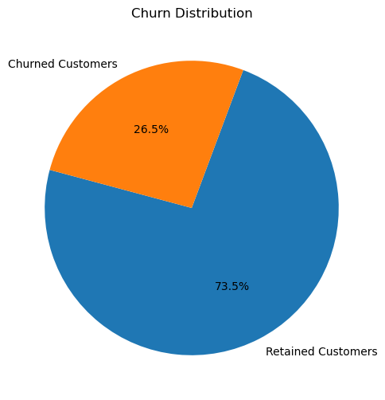

```python
# Churn Distribution
# Pie chart of churned vs. retained customers
labels = ['Retained Customers', 'Churned Customers']
sizes = df['Churn'].value_counts()
plt.figure(figsize=(6, 6))
plt.pie(sizes, labels=labels, autopct='%1.1f%%', startangle=165, explode=(0, 0))
plt.title('Churn Distribution')
plt.show()
```

### 🔥 Step 8: Correlation Heatmap

We generate a correlation heatmap to visualize the strength and direction of relationships between numerical features, including the target variable `Churn`.

- **Positive correlation (closer to +1)** means as one variable increases, the other tends to increase.
- **Negative correlation (closer to -1)** means as one variable increases, the other tends to decrease.
- This helps identify which features are potentially influential in predicting churn, such as `Contract`, `tenure`, and `MonthlyCharges`.

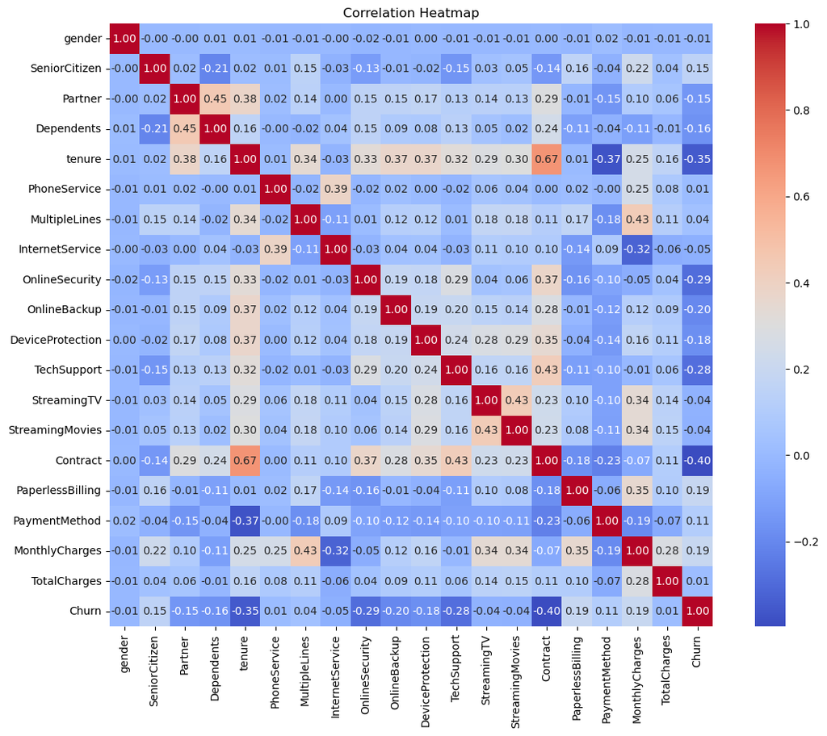

```python
# Correlation Heatmap.
plt.figure(figsize=(14, 10))
sns.heatmap(df.corr(), annot=True, fmt='.2f', cmap='coolwarm', square=True)
plt.title("Correlation Heatmap")
plt.show()
```

### 📊 Step 9: Churn by Categorical Features

To explore how different categorical features relate to churn, we define a function that uses `seaborn.countplot()` to show the distribution of churn across various categories.

We then apply this function to selected features such as:

- **Contract** and **InternetService** (service-related)
- **Partner** and **Dependents** (demographic-related)
- **PaymentMethod**, **SeniorCitizen**, and **gender**

These plots help reveal patterns, such as higher churn among customers with month-to-month contracts or specific payment types.

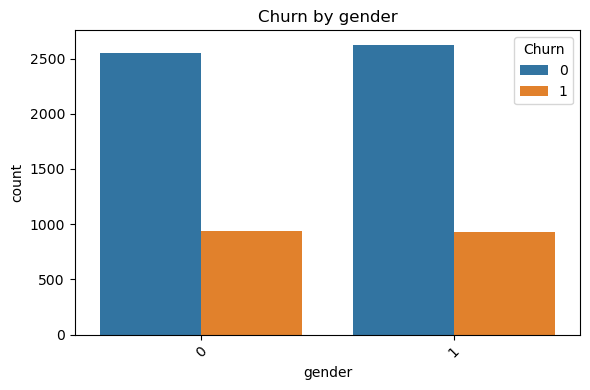

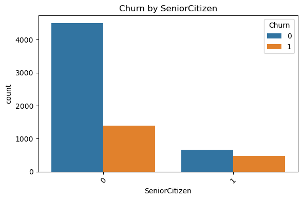

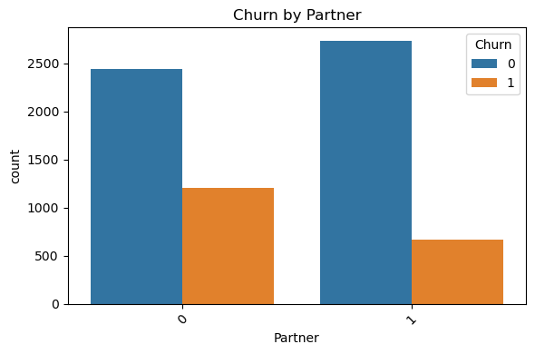

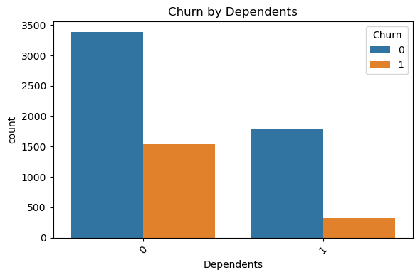

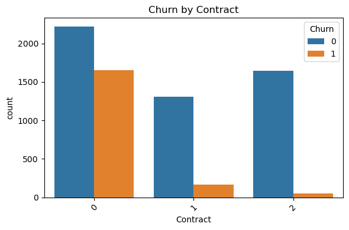

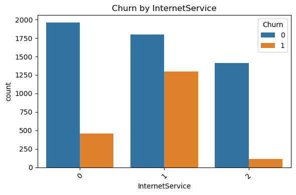

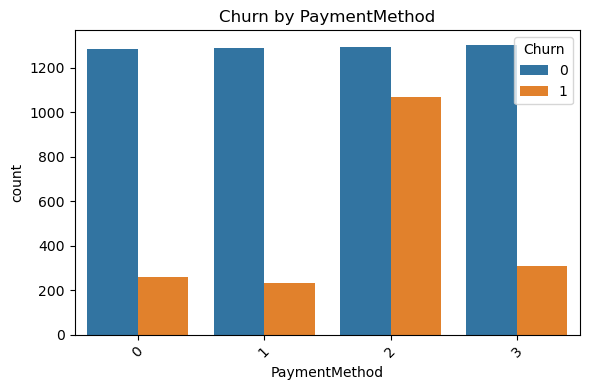

```python
# Churn by Categorical Variables
# Function to plot categorical feature impact on churn
def plot_churn_by_category(col):
    plt.figure(figsize=(6, 4))
    sns.countplot(data=df, x=col, hue='Churn')
    plt.title(f'Churn by {col}')
    plt.xticks(rotation=45)
    plt.tight_layout()
    plt.show()

# Example: Call this for selected categorical features
for feature in ['gender', 'SeniorCitizen', 'Partner', 'Dependents',
                'Contract', 'InternetService', 'PaymentMethod']:
    plot_churn_by_category(feature)
```

### 💰 Step 10: Distribution of Monthly and Total Charges

We use histograms with KDE (Kernel Density Estimate) curves to visualize how **MonthlyCharges** and **TotalCharges** are distributed among customers who churned versus those who didn’t.

- The **MonthlyCharges** plot shows that customers with higher monthly fees tend to churn more.
- The **TotalCharges** plot helps understand long-term spending behavior and its relationship to churn.

These insights are useful for identifying pricing-related churn risk.

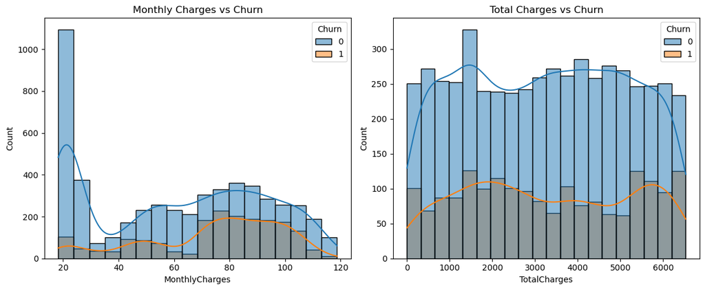

```python
# Distribution of Total Charges and Monthly Charges.
plt.figure(figsize=(12, 5))

# MonthlyCharges distribution
plt.subplot(1, 2, 1)
sns.histplot(data=df, x='MonthlyCharges', hue='Churn', kde=True)
plt.title('Monthly Charges vs Churn')

# TotalCharges distribution
plt.subplot(1, 2, 2)
sns.histplot(data=df, x='TotalCharges', hue='Churn', kde=True)
plt.title('Total Charges vs Churn')

plt.tight_layout()
plt.show()
```

## 🔍 Key EDA Insights:

- **Contract Type and Churn:** Month-to-month customers show higher churn rates compared to long-term contracts.
- **Tenure:** Customers with lower tenure (i.e., new customers) tend to churn more often.
- **Monthly Charges:** Higher monthly charges are correlated with higher churn probability.
- **Online Security & Tech Support:** Absence of these services increases the likelihood of churn.

### 🧪 Step 11: Prepare Features and Split Data

We now prepare the dataset for machine learning by:

- Separating **features (`X`)** from the **target variable (`y`)**, which is the `Churn` column.
- Using `train_test_split()` to divide the data into training (80%) and testing (20%) sets.

This split allows us to train the model on one portion of the data and evaluate its performance on unseen data, ensuring the model generalizes well.

```python
# Prepare Features & Target Variable
# We’ll separate the input features (X) and the target (y = Churn), then split the data into training and testing sets:
# Features (drop target)
X = df.drop('Churn', axis=1)

# Target
y = df['Churn']

# Train-test split (80% train, 20% test)
from sklearn.model_selection import train_test_split
X_train, X_test, y_train, y_test = train_test_split(X, y, test_size=0.2, random_state=42)

print(f"✅ Training set shape: {X_train.shape}")
print(f"✅ Test set shape: {X_test.shape}")
```

```
✅ Training set shape: (5634, 19)
✅ Test set shape: (1409, 19)
```

### 🤖 Step 12: Train Machine Learning Models

We train two classification models to predict customer churn:

- **Logistic Regression**: A linear model often used as a baseline for binary classification tasks.
- **Random Forest Classifier**: An ensemble model that builds multiple decision trees and combines their predictions for improved accuracy and robustness.

Both models are trained on the training dataset (`X_train`, `y_train`), and predictions are made on the test set (`X_test`) for evaluation.

```python
#-Train Models (Logistic Regression & Random Forest)
#We’ll train two simple models for now:

#Logistic Regression (baseline)
#Random Forest Classifier (tree-based model)
# Logistic Regression
log_model = LogisticRegression(max_iter=1000)
log_model.fit(X_train, y_train)
log_preds = log_model.predict(X_test)

# Random Forest
rf_model = RandomForestClassifier(n_estimators=100, random_state=42)
rf_model.fit(X_train, y_train)
rf_preds = rf_model.predict(X_test)
```

### 📊 Step 13: Evaluate Model Performance

We evaluate the predictive performance of both models using the following metrics:

- **Accuracy**: The percentage of correctly predicted observations.
- **Confusion Matrix**: A summary of prediction results, showing True Positives, False Positives, True Negatives, and False Negatives.
- **Classification Report**: Includes precision, recall, and F1-score for each class (churn and no churn).

These metrics help us compare how well each model performs, especially in correctly identifying churners (class `1`), which is often the key goal in churn prediction.

```python
# Evaluate Performance.
from sklearn.metrics import classification_report, confusion_matrix, accuracy_score

# Logistic Regression Evaluation
print("🔍 Logistic Regression:")
print("Accuracy:", accuracy_score(y_test, log_preds))
print("Confusion Matrix:\n", confusion_matrix(y_test, log_preds))
print("Classification Report:\n", classification_report(y_test, log_preds))

# Random Forest Evaluation
print("🔍 Random Forest:")
print("Accuracy:", accuracy_score(y_test, rf_preds))
print("Confusion Matrix:\n", confusion_matrix(y_test, rf_preds))
print("Classification Report:\n", classification_report(y_test, rf_preds))
```

```
🔍 Logistic Regression:
Accuracy: 0.8176011355571328
Confusion Matrix:
 [[930 106]
 [151 222]]
Classification Report:
               precision    recall  f1-score   support

           0       0.86      0.90      0.88      1036
           1       0.68      0.60      0.63       373

    accuracy                           0.82      1409
   macro avg       0.77      0.75      0.76      1409
weighted avg       0.81      0.82      0.81      1409

🔍 Random Forest:
Accuracy: 0.7977288857345636
Confusion Matrix:
 [[949  87]
 [198 175]]
Classification Report:
               precision    recall  f1-score   support

           0       0.83      0.92      0.87      1036
           1       0.67      0.47      0.55       373

    accuracy                           0.80      1409
   macro avg       0.75      0.69      0.71      1409
weighted avg       0.79      0.80      0.79      1409
```

### 📉 Step 14: Visualize Confusion Matrices

We use heatmaps to visualize the confusion matrices for both models:

- **Logistic Regression** shows strong performance in identifying both churners and non-churners, with a slightly higher recall for churn prediction.
- **Random Forest** has slightly higher accuracy for non-churners but misses more actual churn cases.

These visuals help us quickly assess where the models are performing well and where they're making prediction errors (false positives and false negatives).

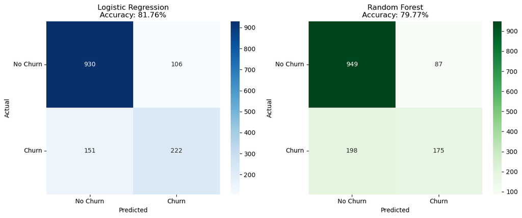

```python
# Confusion matrices
log_cm = [[930, 106], [151, 222]]
rf_cm = [[949, 87], [198, 175]]

fig, axes = plt.subplots(1, 2, figsize=(12, 5))

# Logistic Regression Confusion Matrix
sns.heatmap(log_cm, annot=True, fmt='d', cmap='Blues', ax=axes[0])
axes[0].set_title('Logistic Regression\nAccuracy: 81.76%')
axes[0].set_xlabel('Predicted')
axes[0].set_ylabel('Actual')
axes[0].set_xticklabels(['No Churn', 'Churn'])
axes[0].set_yticklabels(['No Churn', 'Churn'], rotation=0)

# Random Forest Confusion Matrix
sns.heatmap(rf_cm, annot=True, fmt='d', cmap='Greens', ax=axes[1])
axes[1].set_title('Random Forest\nAccuracy: 79.77%')
axes[1].set_xlabel('Predicted')
axes[1].set_ylabel('Actual')
axes[1].set_xticklabels(['No Churn', 'Churn'])
axes[1].set_yticklabels(['No Churn', 'Churn'], rotation=0)

plt.tight_layout()
plt.show()
```

## 📈 Model Performance Summary

- **Logistic Regression:**
  - Accuracy: **81.8%**
  - Strong at predicting **non-churners** (Precision: 86%), but struggles a bit on identifying **churners** (Recall: 60%).
- **Random Forest:**
  - Accuracy: **79.8%**
  - Better at generalization but weaker in detecting churn cases (Recall for churn: 47%).

Logistic Regression shows more balanced performance and may be preferred if interpretability is a key concern.

### 🧠 Step 15: Feature Importance from Random Forest

To understand which variables most influence customer churn, we extract and visualize the **feature importances** from the trained Random Forest model.

This bar plot highlights the top drivers of churn:

- Features like `Contract`, `tenure`, `MonthlyCharges`, and `OnlineSecurity` often rank high.
- These insights are valuable for both business strategy and model refinement.

By focusing on these key variables, the company can design targeted interventions to reduce churn.

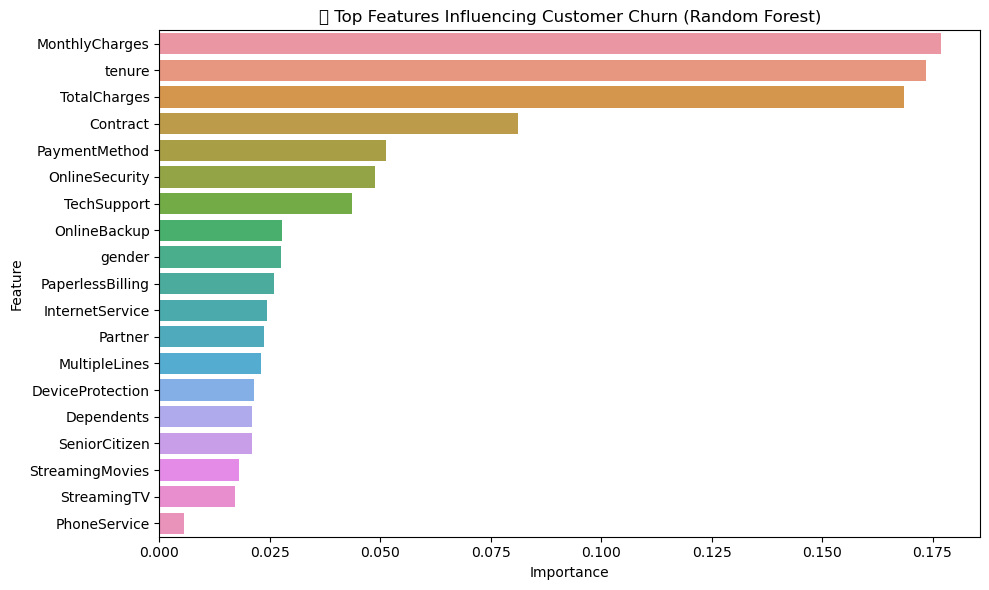

```python
#Feature Importance from Random Forest
#This will help us understand which features are most influential in predicting churn.
# Get feature importances from Random Forest
importances = rf_model.feature_importances_
features = X.columns

# Create a DataFrame for visualization
feature_importance_df = pd.DataFrame({
    'Feature': features,
    'Importance': importances
}).sort_values(by='Importance', ascending=False)

# Plot
plt.figure(figsize=(10, 6))
sns.barplot(x='Importance', y='Feature', data=feature_importance_df)
plt.title('🔍 Top Features Influencing Customer Churn (Random Forest)')
plt.tight_layout()
plt.show()
```

## 🔍 Feature Importance Insights

These can help business teams to prioritize offers, discounts, or engagement efforts.

## ✅ Final Conclusion and Business Insights Report

### 📌 Project Overview

This analysis focused on understanding and predicting customer churn for a telecommunications company using real-world data (Telco Churn Dataset). Through a combination of Exploratory Data Analysis (EDA), feature engineering, and machine learning models (Logistic Regression and Random Forest), we uncovered actionable insights and built predictive tools to help reduce churn and improve customer retention.

### 🤖 Model Performance Summary

Two machine learning models were trained to predict churn:

| Model | Accuracy | Precision (Churn) | Recall (Churn) | F1-Score (Churn) |
| --- | --- | --- | --- | --- |
| Logistic Regression | 81.8% | 0.68 | 0.60 | 0.63 |
| Random Forest | 79.8% | 0.67 | 0.47 | 0.55 |

- **Logistic Regression** performed better overall, offering a balanced trade-off between precision and recall.
- **Random Forest** provided useful feature importance insights but was less effective at identifying actual churners.

### 💡 Business Insights & Recommendations

Based on our analysis, we propose the following **strategic recommendations** to reduce churn and improve customer retention:

#### 🎯 1. Convert Monthly Subscribers to Long-Term Contracts

- Month-to-month customers are significantly more likely to churn.
- **Action:** Offer **loyalty discounts**, **contract-based upgrades**, or **exclusive perks** to convert monthly users to annual plans.

#### 📞 2. Target New Customers Early (First 3 Months)

- Low tenure is a strong churn indicator.
- **Action:** Launch a **high-touch onboarding campaign**, including welcome offers, check-in calls, and early engagement incentives for new customers.

#### 🔒 3. Bundle Support & Security Services

- Lack of Online Security and Tech Support increases churn.
- **Action:** Bundle these services into core packages or offer **free trial periods** to highlight their value.

#### 💰 4. Reassess High-Priced Plans and Customer Value

- Customers with high monthly charges tend to churn.
- **Action:** Implement a **value-based pricing strategy**, or add **bonus services** to higher-tier plans to justify the cost.

#### 📊 5. Use Predictive Models to Create a Churn-Risk Scoring System

- Predictive models allow proactive churn prevention.
- **Action:** Integrate the logistic regression model into CRM systems to assign a **churn risk score** to each customer and **automate retention efforts** (emails, discounts, interventions).

### 🧭 Strategic Takeaway

Reducing churn is not just about predicting who will leave — it's about understanding **why** they leave and building systems and services that make staying the obvious choice. This analysis provides a data-driven roadmap to improve customer retention and long-term profitability.